# Group-Part-Project Stage - IV

## Project Stage - IV (Basic Machine Learning) ddl: 04/28/2023

## Goals

The goal of Stage IV is to utlize machine learning and statistical models to predict the trend of COVID-19 cases / deaths.

### Tasks for Stage IV:

#### Task 1: (70 pts)

- Team: (30)
  - Develop Linear and Non-Linear (polynomial) regression models for predicting cases and deaths in US.
    - Start your data from the first day of infections in US. X-Axis - number of days since the first case, Y-Axis - number of new cases and deaths.
    - Calculate and report Root Mean Square Error (RMSE) for your models (linear and non-linear). Discuss bias versus variance tradeoff.
    - Plot trend line along for the data along with the forecast of 1 week ahead.
    - Describe the trends as compared to other countries.
- Member: (40 pts)
  - Utilize Linear and Non-Linear (polynomial) regression models to compare trends for a single state (each member should choose different state) and its counties (top 5 with highest number of cases). Start your data from the first day of infections.
    - X-Axis - number of days since the first case, Y - Axis number of new cases and deaths. Calcluate error using RMSE.
    - Identify which counties are most at risk. Model for top 5 counties with cases within a state and describe their trends.
    - Utilize the hospital data to calculate the point of no return for a state. Use percentage occupancy / utilization to see which states are close and what their trend looks like.
    - Perform hypothesis tests on questions identified in Stage II
      - e.x. *Does higher employment data (overall employment numbers) lead to higher covid case numbers or more rapid increase in covid cases.*. Here you would compare the covid cases to the state or county level enrichment data to prove or disprove your null hypothesis. In this case there will be a two tail - two sample t-test to see if there is a difference and then one-tail - two sample t-test to show higher or lower.
    - Depending on your type of data you can also perform Chi-square test for categorical hypothesis testing.

#### Task 2: (30 pts)

- Member:
  - For each of the aforemention analysis plot graphs,
    - trend line
    - confidence intervals (error in prediction)
    - prediction path (forecast)

**Deliverable**

- Each member creates separate notebooks for member tasks. Upload all notebooks and reports to Canvas. Do not submit to Github, at least before the submission deadline, to avoid potential plagiarism.

```python
import pandas as pd
import numpy as np
import matplotlib.pyplot as plt
from sklearn.linear_model import LinearRegression
from sklearn.linear_model import LogisticRegression
from sklearn.preprocessing import PolynomialFeatures
from sklearn.metrics import mean_squared_error
from sklearn.model_selection import train_test_split
from math import sqrt
from sklearn.svm import SVR
import warnings
warnings.filterwarnings('ignore')
```

```python
## Loading the comprehensive dataset that includes new cases, deaths, weekly cases(sum, mean,median) and population
confirmed_cases = pd.read_csv('data/covid_comprehensive.csv')
confirmed_cases.head(5)
```

|  | countyFIPS | County Name | State | StateFIPS | 2022-06-01_confirmed | 2022-06-02_confirmed | 2022-06-03_confirmed | 2022-06-04_confirmed | 2022-06-05_confirmed | 2022-06-06_confirmed | ... | 2022-12-14 - 2022-12-21 Mode (Deaths) | 2022-12-21 - 2022-12-28 Sum (Deaths) | 2022-12-21 - 2022-12-28 Mean (Deaths) | 2022-12-21 - 2022-12-28 Median (Deaths) | 2022-12-21 - 2022-12-28 Mode (Deaths) | 2022-12-28 - 2022-12-31 Sum (Deaths) | 2022-12-28 - 2022-12-31 Mean (Deaths) | 2022-12-28 - 2022-12-31 Median (Deaths) | 2022-12-28 - 2022-12-31 Mode (Deaths) | population |
| --- | --- | --- | --- | --- | --- | --- | --- | --- | --- | --- | --- | --- | --- | --- | --- | --- | --- | --- | --- | --- | --- |
| 0 | 1001 | Autauga County | AL | 1 | 6 | 9 | 0 | 0 | 0 | 54 | ... | 0 | 0 | 0.0 | 0.0 | 0 | 0 | 0.0 | 0.0 | 0.0 | 55869 |
| 1 | 1003 | Baldwin County | AL | 1 | 68 | 68 | 0 | 0 | 0 | 247 | ... | 0 | 2 | 0.0 | 0.0 | 0 | 0 | 0.0 | 0.0 | 0.0 | 223234 |
| 2 | 1005 | Barbour County | AL | 1 | 3 | 4 | 0 | 0 | 0 | 5 | ... | 0 | 0 | 0.0 | 0.0 | 0 | 0 | 0.0 | 0.0 | 0.0 | 24686 |
| 3 | 1007 | Bibb County | AL | 1 | 8 | 4 | 0 | 0 | 0 | 22 | ... | 0 | 0 | 0.0 | 0.0 | 0 | 0 | 0.0 | 0.0 | 0.0 | 22394 |
| 4 | 1009 | Blount County | AL | 1 | 4 | 7 | 0 | 0 | 0 | 12 | ... | 0 | 0 | 0.0 | 0.0 | 0 | 0 | 0.0 | 0.0 | 0.0 | 57826 |

5 rows × 682 columns

```python
group_cases_USA = confirmed_cases.sum()
group_cases_USA = group_cases_USA.iloc[218:342]
group_cases_USA = group_cases_USA[group_cases_USA.index.str.contains('Mean')]

group_deaths_USA = confirmed_cases.sum()
group_deaths_USA = group_deaths_USA.iloc[557:-1]
group_deaths_USA = group_deaths_USA[group_deaths_USA.index.str.contains('Mean')]

# Masking Negative values
group_deaths_USA = group_deaths_USA.mask(group_deaths_USA < 0, group_deaths_USA.mean())
```

This function calculates the RMSE of logistic, linear and polynomial regression.  
It then plots the trend line for logistic and polynomial regression model.  
The second plot is the prediction for the next weeks cases.  
It also prints the prediction made by both non linear regression model for the next weeks cases.

```python
def quest1(data):
    temp = data.index


    X =[]
    for i in range(len(temp)):
        X.append(i)
    Y= data.values
    X = np.array(X)
    X= X.reshape(-1,1)
    Y = Y.astype('int')
    Y

    X_train_cases, X_test_cases, y_train_cases, y_test_cases = train_test_split(X, Y, test_size=0.1)
    pr = LinearRegression()
    lrg = LogisticRegression()
    lrl = LinearRegression()
    poly = PolynomialFeatures(degree=3)
    X_poly_train = poly.fit_transform(X_train_cases)
    X_poly_test = poly.transform(X_test_cases)

    pr.fit(X_poly_train, y_train_cases)
    lrg.fit(X_train_cases,y_train_cases)
    lrl.fit(X_train_cases,y_train_cases)

    y_pred_pr = pr.predict(X_poly_test)
    y_pred_lrl = lrl.predict(X_test_cases)
    y_pred_lrg = lrg.predict(X_test_cases)

    rmse_lrl = sqrt( mean_squared_error(y_test_cases, y_pred_lrl))
    rmse_lrg = sqrt(mean_squared_error(y_test_cases, y_pred_lrg))
    rmse_pr = sqrt(mean_squared_error(y_test_cases, y_pred_pr))


    print(f'Logistic regression Root Mean Square Error (RMSE): {round(rmse_lrg,2)}')
    print(f'Linear regression Root Mean Square Error (RMSE): {round(rmse_lrl,2)}')
    print(f'Polynomial regression RMSE: {round(rmse_pr,2)}')
    print('\n')

    diff_pred_act = y_test_cases - y_pred_lrg
    sum_diff = sum(diff_pred_act)
    bias = sum_diff/len(y_test_cases)
    print(f'Bias logistic regression model: {round(bias,2)}')

    pred_var = y_pred_lrg.var()
    print(f'Variance logistic regression model: {round(pred_var)}')

    print('\n')

    diff_pred_lrl = y_test_cases - y_pred_lrl
    sum_diff = sum(diff_pred_lrl)
    bias = sum_diff/len(y_test_cases)
    print(f'Bias Linear regression model: {round(bias,2)}')

    pred_var = y_pred_lrl.var()
    print(f'Variance Linear regression model: {round(pred_var)}')

    print('\n')

    diff_pred_pr = y_test_cases - y_pred_pr
    sum_diff = sum(diff_pred_pr)
    bias = sum_diff/len(y_test_cases)
    print(f'Bias Polynomial regression model: {round(bias,2)}')

    pred_var = y_pred_pr.var()
    print(f'Variance Polynomial regression model: {round(pred_var)}')

    print('\n')

    plt.figure(figsize=(20,15))
    plt.title('Cases along with trend line')
    plt.plot(X,
        lrg.predict(X),
        color='b',
        label = 'Logistic Regression')
    plt.xlabel('Weeks in second half of 2022')
    plt.ylabel('Covid-19 Cases')

    plt.plot(X,Y,marker='o',linestyle='--',label = 'Actual')
    plt.plot(X,pr.predict(poly.fit_transform(X)),label = 'Polynomial Regression')
    plt.legend(
    loc="upper center",
    bbox_to_anchor=(0.5, 1.1),
    ncol=1,
    fancybox=True,
    shadow=True,
    )
    plt.show()

    next_week = []
    for i in range(1):
        next_week.append(i + len(X))
    next_week = np.array(next_week)
    next_week= next_week.reshape(-1,1)

    y_next_week = lrg.predict(next_week)
    X_next = np.append(X, next_week)
    X_next = X_next.reshape(-1,1)
    y_pred_next_pr = pr.predict(poly.fit_transform(X_next))

    plt.figure(figsize=(20,15))
    plt.title('Cases along with trend line and forecast of 1 week ahead')
    plt.plot(X_next,
            lrg.predict(X_next),
            color='b',
            label = 'Logistic Regression')
    plt.xlabel('Weeks in second half of 2022')
    plt.ylabel('Covid-19 Cases')

    plt.plot(X,Y,marker='o',linestyle='--',label = 'Actual')
    plt.plot(X_next,y_pred_next_pr,label = 'Polynomial Regression')
    plt.legend(
        loc="upper center",
        bbox_to_anchor=(0.5, 1.1),
        ncol=1,
        fancybox=True,
        shadow=True,
    )
    plt.show()
    print(f'The prediction for the next week of data using logistic regression is {y_next_week[-1]}')
    print(f'The prediction for the next week of data using Polynomial regression is {int(y_pred_next_pr[-1])}')
```

### Weekly Covid-19 cases for the second half of 2022 using non-linear regression models

```
Logistic regression Root Mean Square Error (RMSE): 31402.83
Linear regression Root Mean Square Error (RMSE): 36031.97
Polynomial regression RMSE: 31492.7


Bias logistic regression model: -2771.0
Variance logistic regression model: 922617083


Bias Linear regression model: 5622.82
Variance Linear regression model: 245866846


Bias Polynomial regression model: 3793.82
Variance Polynomial regression model: 315466802
```

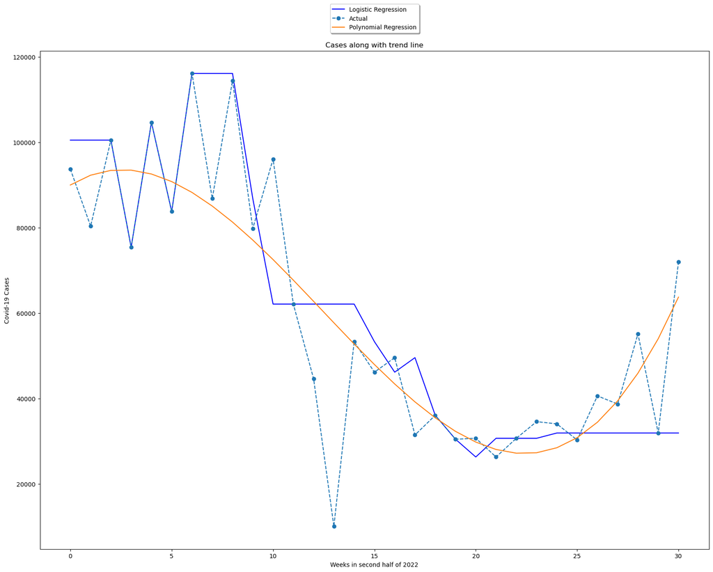

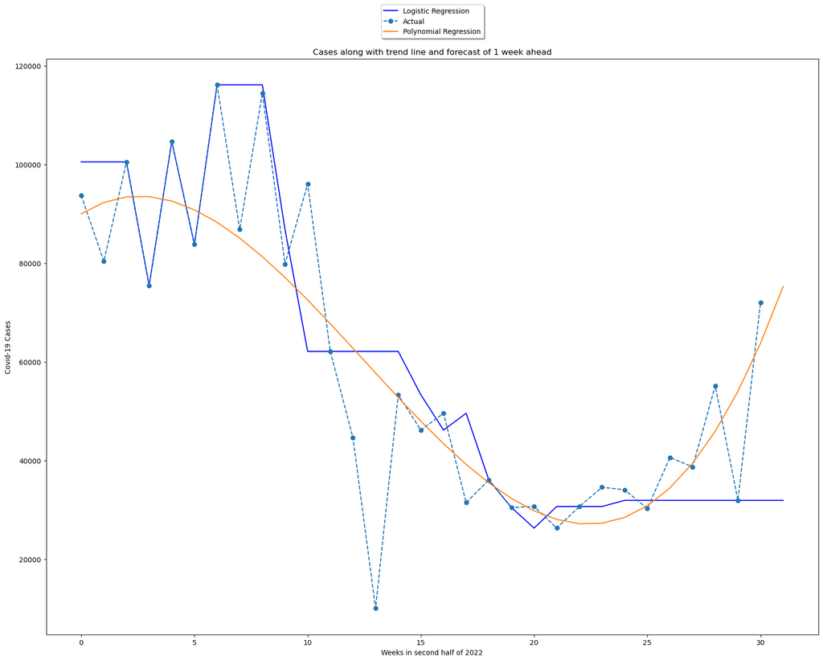

```
The prediction for the next week of data using logistic regression is 31903
The prediction for the next week of data using Polynomial regression is 75290
```

```python
quest1(group_cases_USA)
```

### Weekly Covid-19 deaths for the second half of 2022 using non-linear regression models

```
Logistic regression Root Mean Square Error (RMSE): 272.89
Linear regression Root Mean Square Error (RMSE): 55.52
Polynomial regression RMSE: 56.28


Bias logistic regression model: -191.75
Variance logistic regression model: 48093


Bias Linear regression model: -4.9
Variance Linear regression model: 370


Bias Polynomial regression model: 7.47
Variance Polynomial regression model: 3262
```

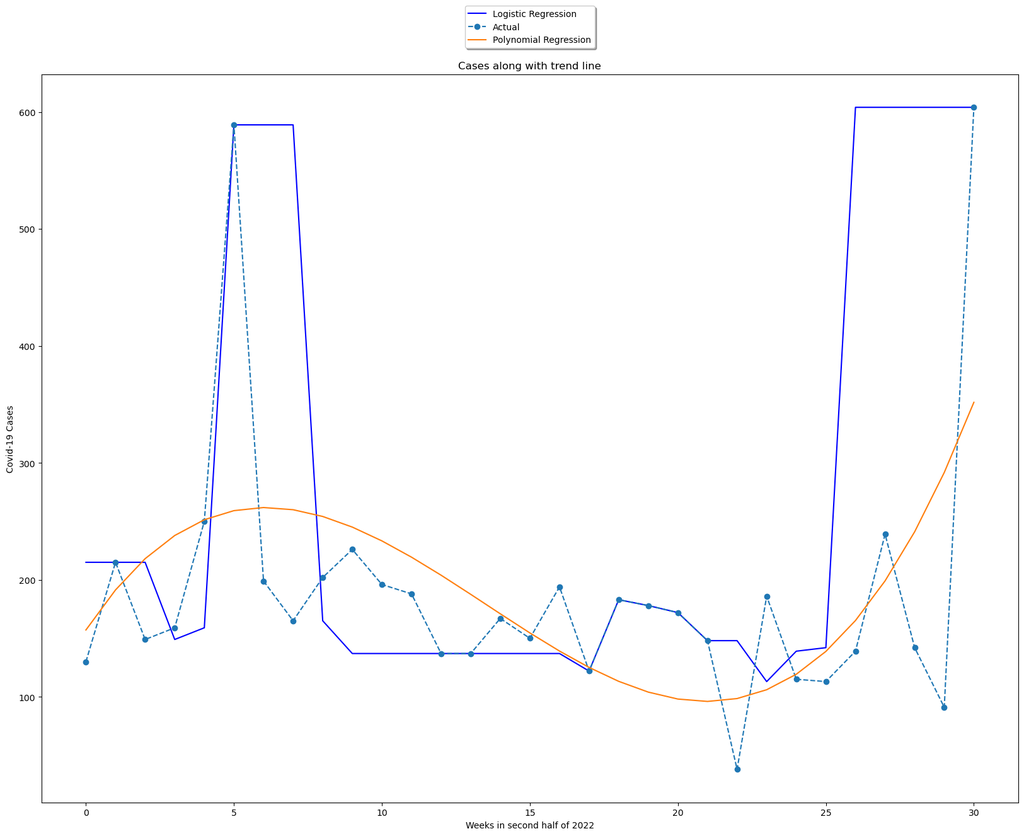

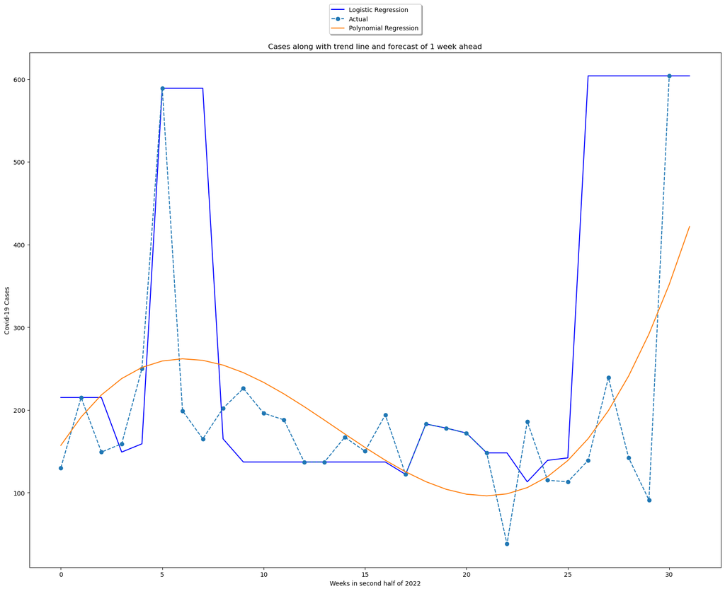

```
The prediction for the next week of data using logistic regression is 604
The prediction for the next week of data using Polynomial regression is 421
```

```python
quest1(group_deaths_USA)
```

### Comparing the U.S. to other Countries

```python
world_df = pd.read_csv("data/owid-covid-data-cases.csv")
world_df
```

|  | iso_code | continent | location | date | total_cases | new_cases | new_cases_smoothed | total_deaths | new_deaths | new_deaths_smoothed | ... | male_smokers | handwashing_facilities | hospital_beds_per_thousand | life_expectancy | human_development_index | population | excess_mortality_cumulative_absolute | excess_mortality_cumulative | excess_mortality | excess_mortality_cumulative_per_million |
| --- | --- | --- | --- | --- | --- | --- | --- | --- | --- | --- | --- | --- | --- | --- | --- | --- | --- | --- | --- | --- | --- |
| 0 | AFG | Asia | Afghanistan | 2020-02-24 | 5.0 | 5.0 | NaN | NaN | NaN | NaN | ... | NaN | 37.746 | 0.5 | 64.83 | 0.511 | 41128772.0 | NaN | NaN | NaN | NaN |
| 1 | AFG | Asia | Afghanistan | 2020-02-25 | 5.0 | 0.0 | NaN | NaN | NaN | NaN | ... | NaN | 37.746 | 0.5 | 64.83 | 0.511 | 41128772.0 | NaN | NaN | NaN | NaN |
| 2 | AFG | Asia | Afghanistan | 2020-02-26 | 5.0 | 0.0 | NaN | NaN | NaN | NaN | ... | NaN | 37.746 | 0.5 | 64.83 | 0.511 | 41128772.0 | NaN | NaN | NaN | NaN |
| 3 | AFG | Asia | Afghanistan | 2020-02-27 | 5.0 | 0.0 | NaN | NaN | NaN | NaN | ... | NaN | 37.746 | 0.5 | 64.83 | 0.511 | 41128772.0 | NaN | NaN | NaN | NaN |
| 4 | AFG | Asia | Afghanistan | 2020-02-28 | 5.0 | 0.0 | NaN | NaN | NaN | NaN | ... | NaN | 37.746 | 0.5 | 64.83 | 0.511 | 41128772.0 | NaN | NaN | NaN | NaN |
| ... | ... | ... | ... | ... | ... | ... | ... | ... | ... | ... | ... | ... | ... | ... | ... | ... | ... | ... | ... | ... | ... |
| 260562 | ZWE | Africa | Zimbabwe | 2023-02-23 | 263921.0 | NaN | NaN | 5663.0 | 0.0 | 0.143 | ... | 30.7 | 36.791 | 1.7 | 61.49 | 0.571 | 16320539.0 | NaN | NaN | NaN | NaN |
| 260563 | ZWE | Africa | Zimbabwe | 2023-02-24 | 263921.0 | NaN | NaN | 5663.0 | 0.0 | 0.143 | ... | 30.7 | 36.791 | 1.7 | 61.49 | 0.571 | 16320539.0 | NaN | NaN | NaN | NaN |
| 260564 | ZWE | Africa | Zimbabwe | 2023-02-25 | 263921.0 | NaN | NaN | 5663.0 | 0.0 | 0.143 | ... | 30.7 | 36.791 | 1.7 | 61.49 | 0.571 | 16320539.0 | NaN | NaN | NaN | NaN |
| 260565 | ZWE | Africa | Zimbabwe | 2023-02-26 | 263921.0 | NaN | NaN | 5663.0 | 0.0 | 0.143 | ... | 30.7 | 36.791 | 1.7 | 61.49 | 0.571 | 16320539.0 | NaN | NaN | NaN | NaN |
| 260566 | ZWE | Africa | Zimbabwe | 2023-02-27 | 263921.0 | NaN | NaN | 5663.0 | 0.0 | 0.143 | ... | 30.7 | 36.791 | 1.7 | 61.49 | 0.571 | 16320539.0 | NaN | NaN | NaN | NaN |

260567 rows × 67 columns

```
Polynomial regression Root Mean Square Error (RMSE) for China: 119920.72
Polynomial regression Root Mean Square Error (RMSE) for Japan: 925635.78
Polynomial regression Root Mean Square Error (RMSE) for India: 2535835.83
Polynomial regression Root Mean Square Error (RMSE) for United States: 4726324.8
```

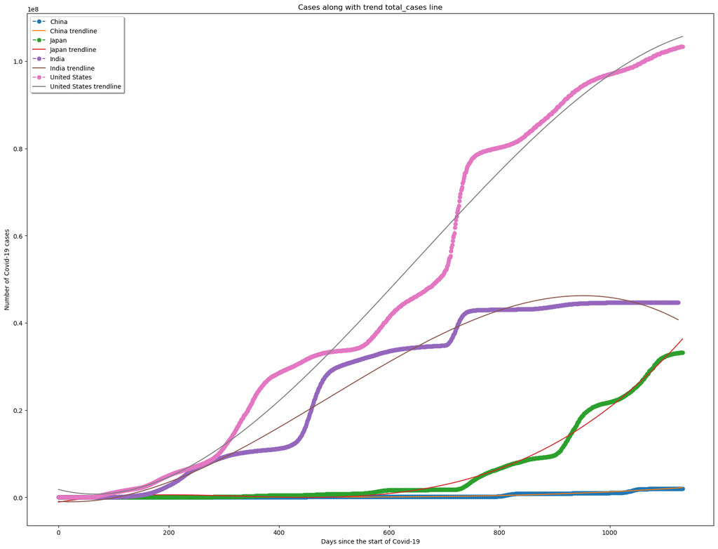

```
Polynomial regression Root Mean Square Error (RMSE) for China: 12509.39
Polynomial regression Root Mean Square Error (RMSE) for Japan: 1.0415629691676637e+18
Polynomial regression Root Mean Square Error (RMSE) for India: 9.278251376311277e+17
Polynomial regression Root Mean Square Error (RMSE) for United States: 1.5282647601864164e+18
```

[figure not shown]

```python
def question1_world(dataframe, columns, countries):
    plt.figure(figsize=(20,15))
    for country in countries:
        country_df = dataframe[dataframe['location'] == country][columns]
        temp = country_df.index

        X =[]
        for i in range(len(temp)):
            X.append(i)
        Y = country_df.values
        X = np.array(X)
        X= X.reshape(-1,1)
        Y = Y.astype('int')

        X_train_cases, X_test_cases, y_train_cases, y_test_cases = train_test_split(X, Y, test_size=0.1)

        lrl = LinearRegression()
        poly = PolynomialFeatures(degree=3)
        X_poly_fit = poly.fit_transform(X_train_cases)
        lrl.fit(X_poly_fit,y_train_cases)

        y_pred_lrl = lrl.predict(poly.transform(X_test_cases))

        rmse_lrl = sqrt( mean_squared_error(y_test_cases, y_pred_lrl))

        print(f'Polynomial regression Root Mean Square Error (RMSE) for {country}: {round(rmse_lrl,2)}')

        # Plot the data for the current country
        plt.plot(X,Y,marker='o',linestyle='--',
            label=country)

        plt.plot(X, lrl.predict(poly.transform(X)), label=f'{country} trendline')

    plt.title(f'Cases along with trend {columns} line')
    plt.legend(fancybox=True, shadow=True)
    plt.xlabel('Days since the start of Covid-19')
    plt.ylabel('Number of Covid-19 cases')
    plt.show()

question1_world(world_df, 'total_cases', ['China','Japan','India', 'United States'])
question1_world(world_df, 'total_deaths', ['China','Japan','India', 'United States'])
```

## Analysis

```python
def analysis_world(dataframe, countries):
    for country in countries:
        country_df = dataframe[dataframe['location'] == country]
        total_cases = country_df['total_cases'].iloc[-1]
        total_deaths = country_df['total_deaths'].iloc[-1]
        population = country_df['population'].iloc[-1]

        print(f"Country: {country}")
        print(f"Total Cases: {total_cases}")
        print(f"Total Deaths: {total_deaths}")
        print(f"Population: {population}")
        print("\n")
analysis_world(world_df, ['China','Japan','India', 'United States'])
```

```
Country: China
Total Cases: 2023904.0
Total Deaths: 87468.0
Population: 1425887360.0


Country: Japan
Total Cases: 33212438.0
Total Deaths: 72328.0
Population: 123951696.0


Country: India
Total Cases: 44687597.0
Total Deaths: 530771.0
Population: 1417173120.0


Country: United States
Total Cases: 103389954.0
Total Deaths: 1119550.0
Population: 338289856.0
```